# Login Page

Login from [LoginPage](https://math.cgu.edu.tw/Login_logiN/index_1.html)

## Date

1. 2021-05-25,
   - Fubini Theorem, with example $$\underset{\{1\le y\le2,0\le x\le1\}}{\iint} 3x^2y d A$$
   - Example, $1-2xy^2$ $$\iint\limits_{\{0\le x\le2,-1\le y\le1\}}(1-2xy^2) d A$$
   - Example, Double Integration on non-rectangular area
   - Iterated Integral, order of Integration
2. 2021-05-27
   - Double Integral in Polar Cordinates

```python
from IPython.display import Video,Image
```

# 2021-05-25

## Fubini Theorem

```python
Video(data="video/12-1-Fubini.mp4")
```

[video not shown]

## Example-2

$$\iint\limits_{\{0\le x\le2,-1\le y\le1\}}(1-2xy^2) d A$$

```python
Video(data="video/Fubini-ex2.mp4")
```

[video not shown]

## Example-3

$$ \underset{D}{\iint} (x + y) d A $$ where

\begin{eqnarray*} D & = & \left\{ (x, y) \middle| 1 \leqslant x \leqslant \sqrt{y}, 1 \leqslant y \leqslant 4 \right\}\\ & = & \left\{ (x, y) \middle| x^2 \leqslant y \leqslant 4, 1 \leqslant x \leqslant 2 \right\} \end{eqnarray*}

```python
Video(data="video/Fubini-ex3.mp4")
```

[video not shown]

## Example-4

Evaluate $$\underset{0\le y\le1,y\le x\le1}{\iint} \frac{\sin x}{x} d A$$

Keypoint: $$D=\{0\le y\le1,y\le x\le1 \} = \{0\le x\le1,0\le y\le x\}$$

```python
Video(data="video/Fubini-ex4.mp4")
```

[video not shown]

## Double integral in Polar/General Coordinates

1. In polar coordinate system, for any $(x,y) \in \mathbb{R}^2$, we have

$$ x = r \cos \theta, y = r \sin \theta $$

where $r$ is the distance between $(x, y)$ and origin and $\theta$ is the angle between the line, connecting $(x, y)$ and origin, and $X$-axis.

1. (**Fubini Theorem in general Coordinates, $(U,V)$**) Suppose that all the points $(x, y) \in D$ can be transformed as: $$ x = \phi (u, v), y = \psi (u, v) . $$ Then the double integral can be evaluated as followed: $$ \iint\limits_D f (x, y) d A = \iint\limits_D f (x, y) d x dy =\underset{D}{\iint} f (\phi (u, v), \psi (u, v)) \left||J|\right| d u d v $$ where $||J||$ is the absolute value of determinant of Jacobian, $J$, where its deteminant is equal to:

\begin{eqnarray*} |J| & = & \left|\frac{\partial (x,y)}{\partial(u,v)}\right|=\left| \begin{matrix} \frac{\partial x}{\partial u} & \frac{\partial x}{\partial v}\\ \frac{\partial y}{\partial u} & \frac{\partial y}{\partial v} \end{matrix} \right|\\ & = & \frac{\partial x}{\partial u} \cdot \frac{\partial y}{\partial v} - \frac{\partial x}{\partial v} \cdot \frac{\partial y}{\partial u} \end{eqnarray*}

1. Especially, in **Polar Coordinate, $(r,\theta)$** system, we have

$$ x = r \cos \theta, y = r \sin \theta $$

where $r$ is the distance between $(x, y)$ and origin and $\theta$ is the angle between the line, connecting $(x, y)$ and origin, and $X$-axis. In this case,

$$ \frac{\partial x}{\partial r} = \cos \theta, \frac{\partial x}{\partial \theta} = - r \sin \theta, \frac{\partial y}{\partial r} = \sin \theta \text{ and } \frac{\partial y}{\partial \theta} = r \cos \theta $$

and $|J| = r$ since

\begin{eqnarray*} |J| & = & \left| \begin{matrix} \frac{\partial x}{\partial r} & \frac{\partial x}{\partial \theta}\\ \frac{\partial y}{\partial r} & \frac{\partial y}{\partial \theta} \end{matrix} \right|\\ & = & \cos \theta \cdot r \cos \theta - (- r \sin \theta) \cdot \sin \theta\\ & = & r \end{eqnarray*}

In other words, the Fubini Theorem in Polar Coordinates is: $$ \iint\limits_D f (x, y) d A = \underset{D}{\iint} f (r\cos\theta, r\sin\theta) r d r d \theta $$

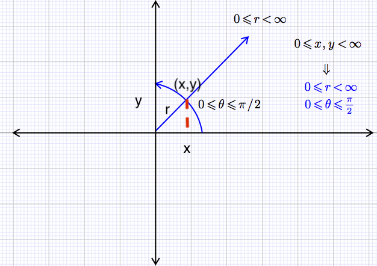

```python
Image("imgs/8/cal7-37.png",width=600)
```

## Example

[figure not shown]

1. If $D = \left\{ (x, y) | - 2 \le x \le 2, 0 \le y \le \sqrt{4 - x^2} \right\}$, then

\begin{eqnarray*} \iint\limits_D 1 d A & = & \int^2_{- 2} d x \int^{\sqrt{4 - x^2}}_0 d y\\ & = & \int^2_{- 2} \sqrt{4 - x^2} d x\\ & = & \frac{1}{2} 2^2 \pi = 2 \pi \end{eqnarray*}

i.e. the area of half circle, $D$, is $2 \pi$.
**Note** $$\text{Volume}=\iint_A 1 dA=1\cdot|A|=|A|,\text{ i.e. area of }A$$

1. Find the volume of the semi-sphere above $X$-$Y$ plane with radius 2, i.e. $$ \iint\limits_{\{(x, y) | x^2 + y^2 \leqslant 4\}} \sqrt{4 - x^2 - y^2} d A $$

**Sol:** Since $\{(x, y) | x^2 + y^2 \leqslant 4\} = \{(r, \theta) |0 \leqslant r \leqslant 2, 0 \leqslant \theta \leqslant 2 \pi\}$

[figure not shown]

and $|J| = r$. Then

\begin{eqnarray*} \iint\limits_{\{(x, y) | x^2 + y^2 \le 4\}} \sqrt{4 - x^2 - y^2} d A & = & \iint\limits_{\{(r, \theta) |0 \le r\le 2, 0 \leqslant \theta \le 2 \pi\}} \sqrt{4 - r^2} \cdot r d r d \theta\\ & = & \int^{2 \pi}_0 d \theta \int^2_0 r \sqrt{4 - r^2} d r\\ & = & \left.\int^{2 \pi}_0 \left( - \frac{1}{3} (4 - r^2)^{3 / 2} \right) \right| ^2_0 d \theta\\ & = & \int^{2 \pi}_0 \frac{8}{3} d \theta\\ & = & \frac{16 \pi}{3} \end{eqnarray*}

i.e. half of volume of ball with radius $2$, reference the following:

[figure not shown]

```python
Video(data="video/Fubini_Polar.mp4")
```

[video not shown]

## Example

Evaluate the integral $$\Large{\int^{\infty}_0 e^{- x^2} d x}$$

**Sol:** Let $I = \int^{\infty}_0 e^{- x^2} d x$. Then $I = \int^{\infty}_0 e^{- y^2} d y$ by changing the dummy variable $x$ into $y$. Consider the product:

\begin{eqnarray*} I^2 & = & I \cdot I\\ & = & \int^{\infty}_0 e^{- x^2} d x \cdot \int^{\infty}_0 e^{- y^2} d y\\ & = & \int^{\infty}_0 \int^{\infty}_0 e^{- x^2 - y^2} d x d y\\ & = & \int^{\pi / 2}_0 \int^{\infty}_0 e^{- r^2} \cdot r d r d \theta\\ & = & \int^{\pi / 2}_0 \frac{1}{2} d \theta = \frac{\pi}{4} \end{eqnarray*}\begin{eqnarray*} D & = & \{ (x, y) | 0 \leqslant x, y < \infty \}\\ & = & \{ (r, \theta) | 0 \leqslant r < \infty, 0 \leqslant \theta \leqslant \pi / 2 \} \end{eqnarray*}

i.e. the whole first quadrant. This implies $I = \frac{\sqrt{\pi}}{2}$ .

**Note:** The related formula are listed:

**1.** By symmetry, we have

$$ \Large{\int^{\infty}_{- \infty} e^{- x^2} d x = 2 \int^{\infty}_0 e^{- x^2} d x = \sqrt{\pi} }$$

**2.** To prove

$$ \Large{\int^{\infty}_{- \infty} \frac{1}{\sqrt{2 \pi} \sigma} e^{\frac{- (x - \mu)^2}{2 \sigma^2}} d x = 1} $$

change the variable by substitution of $$\Large {t = \frac{x - \mu}{\sqrt{2} \sigma} \text{ and }d t = \frac{d x}{\sqrt{2} \sigma}}$$.

Also

$$ \Large{x \left| \underset{- \infty}{\overset{\infty}{\uparrow}}\right. \Longrightarrow t = \frac{x - \mu}{\sqrt{2} \sigma} \left| \underset{- \infty}{\overset{\infty}{\uparrow}} \right.}$$

Then

\begin{eqnarray*} \Large{ \int^{\infty}_{- \infty} \frac{1}{\sqrt{2 \pi} \sigma} e^{\frac{- (x - \mu)^2}{2 \sigma^2}} d x }& = & \int^{\infty}_{- \infty} \frac{1}{\sqrt{\pi}} e^{- t^2} d t\\ & = & \frac{1}{\sqrt{\pi}} \cdot \sqrt{\pi} = 1 \end{eqnarray*}

**3.** Similarly, we can also calculate $$\Large{\int^{\infty}_{- \infty} \frac{x}{\sqrt{2 \pi} \sigma} e^{\frac{- (x - \mu)^2}{2 \sigma^2}} d x = \mu}$$ Using the substitution, $$t = \frac{x - \mu}{\sqrt{2} \sigma}$$ we have:

\begin{eqnarray*} \Large{\int^{\infty}_{- \infty} \frac{x}{\sqrt{2 \pi} \sigma} e^{\frac{- (x - \mu)^2}{2 \sigma^2}} d x }& = & \int^{\infty}_{- \infty} \frac{\mu}{\sqrt{2 \pi} \sigma} e^{\frac{- (x - \mu)^2}{2 \sigma^2}} d x + \int^{\infty}_{- \infty} \frac{x - \mu}{\sqrt{2 \pi} \sigma} e^{\frac{- (x - \mu)^2}{2 \sigma^2}} d x\\ & = & \mu + \int^{\infty}_{- \infty} \frac{t}{\sqrt{\pi}} e^{- t^2} d t\\ & = & \mu \end{eqnarray*}

The last result holds since the definite integral of odd function over interval symmetry with respect to $0$.

We can also describe the result by the graphs of such functions.

## Conclusion

1. **Shift invariance**: for any $\mu\in\mathbb{R}$ $$\Large{\int^{\infty}_{- \infty} e^{-(x-\mu)^2}dx= \int^{\infty}_{- \infty} e^{-x^2}dx=\sqrt{\pi}}$$
2. **Scaling**: or any $a\in\mathbb{R}$ $$\Large{\int^{\infty}_{- \infty} e^{-a^2x^2}dx=\frac{\sqrt \pi}{|a|}}$$

**Question:** What is the value of integral below: $$\Large{\int^{\infty}_{- \infty} e^{-(x+1)^2/3}dx}$$ Answer: $$\Huge{\color{white}{\sqrt{3\pi}}}$$

```python
Video(data="video/Normal_integration.mp4")
```

[video not shown]